# 07_rc_software

**RC Software**

By Prof. Seungchul Lee  
http://iai.postech.ac.kr/  
Industrial AI Lab at POSTECH

- Please submit the following files after today's class.
  - arduino files
  - Demonstration videos of your RC car
- TA's E-mail : juwonna7@postech.ac.kr
  - The title of your mail should be "[MECH199-01][Drone & RC Car] (Group Name) WEEK8"

# 1. Let's move out

## 1.1 Drive Motor

Let's drive motors you assembled last class.  
In this class, each two motors on left and right drive together.

- First, set pinMode for each pin of motor drive from datasheet

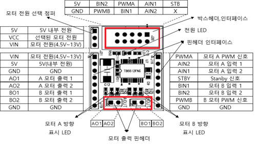

- Fill arduino code below.

> ```
> // arduino code
> int PIN_STNB = 3
> int PIN_AIN1 = 4
> int PIN_AIN2 = 5
> int PIN_PWMA = 6
> // and so on
> ```

> ```
> void setup(){
>     pinMode(PIN_STNB, OUTPUT);
>     pinMode(PIN_AIN1, OUTPUT);
>     pinMode(PIN_AIN2, OUTPUT);
>     pinMode(PIN_PWMA, OUTPUT);
>     // and so on
> }
> ```

- Drive motors with proper digitalWrite functions.

> ```
> void loop(){
>     digitalWrite(PIN_STNB, HIGH);
>     digitalWrite(PIN_AIN1, HIGH);
>     digitalWrite(PIN_AIN2, LOW);
>     analogWrite(PIN_PWMA, 255);
>     // and so on
> }
> ```

## 1.2. Change Speed and Direction

- Try the speed and steering control of the RC car with your own code.
- Add analogWrite function on your code.

# 2. Modulization

## 2.1. Create Functions

Create functions for 8-way move. LEFT and RIGHT be replaced with TURNCW and TURNCCW. Each functions should have parameters to adjust speed or direction(how much rotate).

> ```
> void FORWARD(int speed){
>   digitalWrite( , );
>   digitalWrite( , );
>   analogWrite( , speed);
>   // fill your code
> }
> void FORWARD_LEFT(int speed, int direction){
>   digitalWrite( , );
>   digitalWrite( , );
>   analogWrite( , speed);
>   // fill your code
> }
> ```

or you can use speed of left / right motors as parameter of FORWARD_LEFT

> ```
> void FORWARD_LEFT(int left_spd, int right_spd){
>   digitalWrite( , );
>   digitalWrite( , );
>   analogWrite( , speed);
>   // fill your code
> }
> ```

# 3. Make your scenarios

Make sequence of motions with function you made.  
delay(milliseconds); function of ArduinoIDE may be useful.

> ```
> FORWARD_LEFT(100, 45); // second motion
>     delay(1000);
>     // fill your code
> }
> ```

## 3.1. Add LED Function

Should a car tail lights up when turn?

- Write your code for LEDs with your own logic.

```python
%%javascript
$.getScript('https://kmahelona.github.io/ipython_notebook_goodies/ipython_notebook_toc.js')
```